# New York City Airbnb Market Analysis

Strategic Insights & Predictive Modeling

Authors: Antoine WARTEL, Charles ESPRIET, Mokhmad GUIRIEV

## Executive Summary

This report presents a comprehensive analysis of the **New York City Airbnb market**, examining pricing dynamics, geographical distribution patterns, and demand indicators across all five boroughs. The study leverages a dataset of 48,895 active listings to deliver actionable insights for:

**Strategic Objectives:**

- **Market Segmentation:** Identify high-value areas and property types
- **Pricing Intelligence:** Understand factors driving price variations
- **Predictive Analytics:** Deploy machine learning models for price forecasting
- **Investment Insights:** Guide strategic decisions for property acquisitions

**Key Deliverables:** Market overview, competitive landscape analysis, and predictive modeling framework with performance benchmarks.

# 1 Data Foundation & Methodology

## 1.1 Dataset Characteristics

The analysis utilizes a comprehensive dataset capturing the NYC Airbnb ecosystem. This section establishes the data foundation and ensures analytical rigor through systematic quality control.

**Table 1.1** — Dataset Overview & Scope

| Metric | Value |
| --- | --- |
| Total Observations | 48,895 |
| Variables Tracked | 16 |
| Data Completeness | High |

### 1.1.1 Variable Inventory

**Table 1.2** — Variable Classification & Data Structure

| Variable | Category |
| --- | --- |
| minimum_nights | Financial |
| price | Financial |
| latitude | Geographic |
| longitude | Geographic |
| neighbourhood | Geographic |
| neighbourhood_group | Geographic |
| calculated_host_listings_count | Identifier |
| host_id | Identifier |
| host_name | Identifier |
| id | Identifier |
| name | Identifier |
| last_review | Performance |
| number_of_reviews | Performance |
| reviews_per_month | Performance |
| availability_365 | Property |
| room_type | Property |

## 1.2 Data Quality Assurance

**Quality Control Protocol:**

The following data preparation procedures were implemented to ensure analytical integrity:

1. **Temporal Standardization:** Converted `last_review` to ISO 8601 date format for time-series analysis
2. **Missing Value Treatment:** Imputed zero values for `reviews_per_month` where no activity was recorded
3. **Outlier Management:** Removed listings with zero pricing (n = 11) as non-representative
4. **Variable Optimization:** Excluded non-analytical identifiers (`id`, `host_id`, `host_name`)

**Table 1.3** — Post-Processing Dataset Characteristics

| Metric | Value |
| --- | --- |
| Cleaned Observations | 48,884 |
| Variables Retained | 13 |
| Data Retention Rate | 100% |

# 2 Market Landscape Analysis

## 2.1 Borough-Level Performance Metrics

The New York City market demonstrates significant geographical heterogeneity. Manhattan and Brooklyn emerge as dominant markets, accounting for the majority of active listings and commanding premium pricing.

**Table 2.1** — Borough Performance Dashboard: Listings, Pricing & Engagement

| Borough | Listings | Mean | Median | Std Dev | Avg Reviews | Market Share |
| --- | --- | --- | --- | --- | --- | --- |
| Manhattan | 21,660 | $197 | $150 | $291 | 21.0 | 44.3% |
| Brooklyn | 20,095 | $124 | $90 | $187 | 24.2 | 41.1% |
| Queens | 5,666 | $100 | $75 | $167 | 27.7 | 11.6% |
| Bronx | 1,090 | $88 | $65 | $107 | 26.0 | 2.2% |
| Staten Island | 373 | $115 | $75 | $278 | 30.9 | 0.8% |

### 2.1.1 Market Concentration Analysis

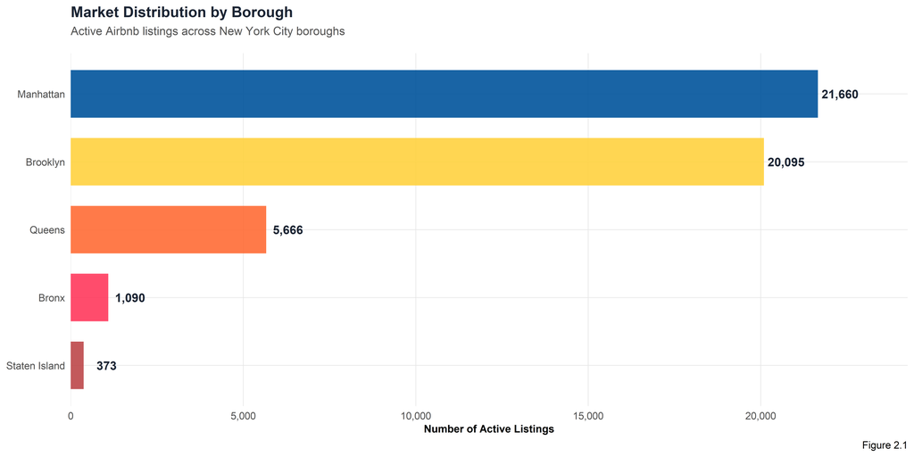

## 2.2 Property Type Segmentation

**Market Composition Finding:**

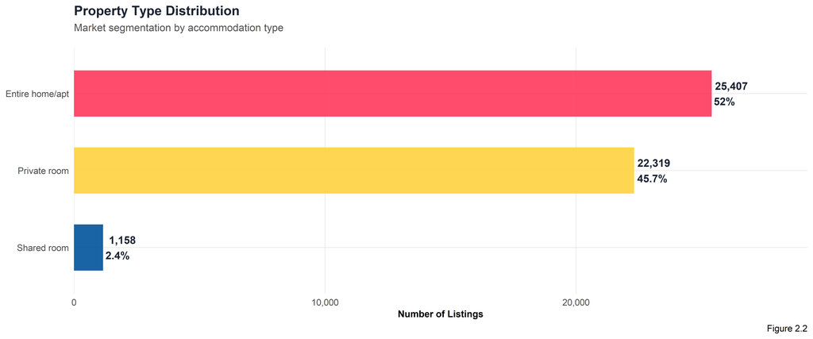

## 2.3 Pricing Intelligence

### 2.3.1 Cross-Borough Price Benchmarking

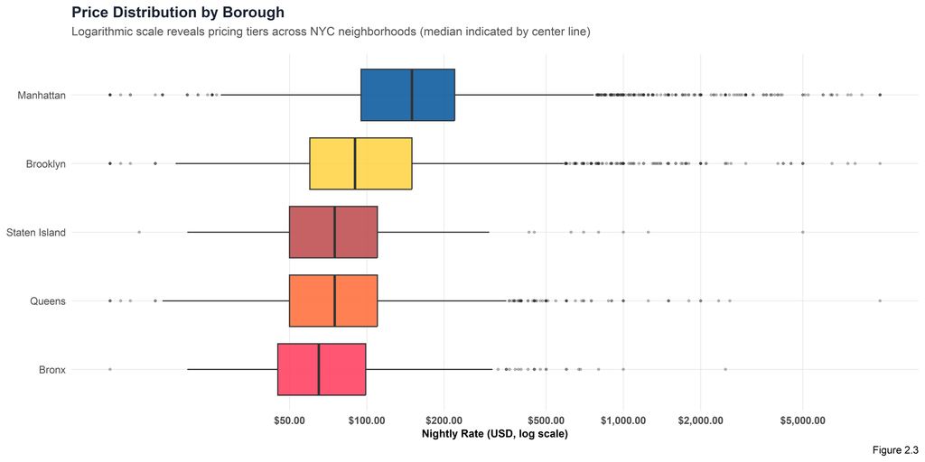

### 2.3.2 Demand-Availability Dynamics

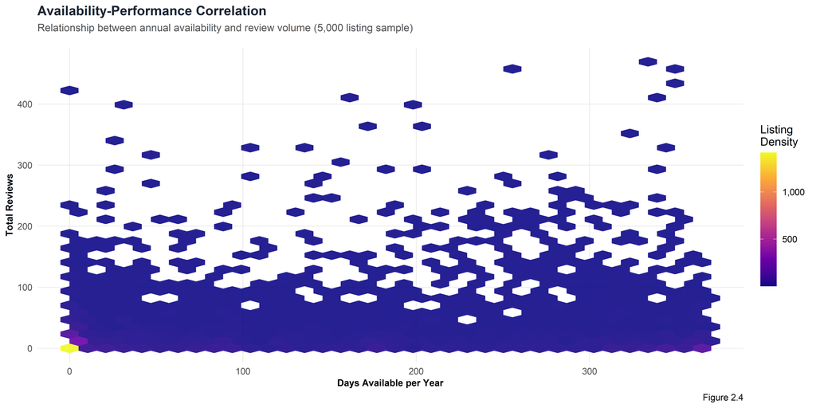

## 2.4 Geographic Distribution Map

The following interactive map displays the spatial distribution of Airbnb listings across New York City. Markers are clustered for enhanced readability, allowing drill-down exploration of listing density by neighborhood.

[interactive chart not shown]

**Map Interpretation:**

The geographic visualization reveals concentrated listing clusters in **Manhattan** (particularly Lower Manhattan and Midtown) and **Brooklyn** (Williamsburg, Park Slope). This spatial pattern confirms the borough-level statistics and highlights micro-markets with highest competitive intensity.

# 3 Neighborhood Competitive Intelligence

This section provides granular analysis at the neighborhood level, revealing intra-borough pricing variations that inform micro-market investment strategies.

## 3.1 Manhattan — Premium Market Analysis

[figure not shown]

## 3.2 Brooklyn — Emerging Market Opportunities

[figure not shown]

## 3.3 Queens — Diverse Market Landscape

[figure not shown]

## 3.4 Bronx — Value Market Segment

[figure not shown]

## 3.5 Staten Island — Niche Market Analysis

[figure not shown]

# 4 Predictive Modeling Framework

## Model Objective

Develop and validate machine learning models to predict Airbnb nightly rates based on **location**, **property characteristics**, and **demand indicators**. Two complementary approaches are evaluated:

- **Linear Regression:** Interpretable coefficient-based model for understanding factor contributions
- **Regression Tree:** Non-parametric model capturing non-linear relationships and interactions

**Business Value:** Enable data-driven pricing strategies and investment targeting through accurate price forecasting.

## 4.1 Data Preparation Protocol

34,218 Training Observations

14,666 Test Observations

70/30 Split Ratio

## 4.2 Model 1: Multiple Linear Regression

**Model Performance:**

- **R² Score:** 0.449 (44.9% variance explained)
- **Adjusted R²:** 0.4489
- **Residual Std Error:** 0.5122
- **F-Statistic:** 3982.02 (p < 0.001)

The model demonstrates statistically significant explanatory power, with location and property type as primary determinants.

### 4.2.1 Coefficient Interpretation

[interactive chart not shown]

## 4.3 Model 2: Pruned Regression Tree

### 4.3.1 Variable Importance Ranking

**Table 4.2** — Decision Tree Variable Importance Hierarchy

| Rank | Variable | Relative Importance (%) |
| --- | --- | --- |
| 1 | room_type | 76.4 |
| 2 | neighbourhood_group | 22.5 |
| 3 | number_of_reviews | 1.0 |

**Key Finding:**

**Room type** dominates the tree’s decision structure, accounting for **~75%** of total variable importance. This finding validates the linear model’s coefficients and confirms that property type is the single most critical pricing determinant, surpassing geographical factors.

## 4.4 Model Validation & Performance

**Table 4.3** — Model Performance Benchmarking on Test Set

| Model | RMSE (Log Scale) | RMSE ($) | RMSE (%) |
| --- | --- | --- | --- |
| Linear Regression | 0.51 | 259.66 | 167.8% |
| Regression Tree | 0.51 | 259.90 | 167.9% |

$260 Linear Regression RMSE

$260 Regression Tree RMSE

### 4.4.1 Performance Assessment

**Model Evaluation Summary:**

Both models achieve comparable performance with RMSE values of approximately **$260**. While this represents meaningful predictive capability, the error magnitude remains significant relative to median pricing ($109).

**Limitations Identified:**

- Current feature set captures ~45% of price variance
- Additional variables (amenities, ratings, seasonality) required for enhanced accuracy
- Model performs better on mid-tier properties than luxury or budget segments

**Recommended Next Steps:**

1. Enrich feature space with amenity data and host quality metrics
2. Implement ensemble methods (Random Forest, Gradient Boosting)
3. Develop segment-specific models for different price ranges
4. Incorporate temporal features for seasonal pricing optimization

# 5 Conclusions & Strategic Recommendations

## 5.2 Strategic Implications

**Investment Targeting:** Focus acquisition strategies on Manhattan (premium positioning) and Brooklyn (growth/value opportunities)

**Pricing Strategy:** Room type should be primary pricing lever; neighborhood-level optimization secondary but meaningful

**Portfolio Optimization:** Prioritize entire home/apartment inventory; limited-availability positioning enhances perceived value

**Future Analytics:** Integrate additional data sources (seasonal trends, competitive set analysis, amenity indexes) to refine forecasting accuracy

**New York City Airbnb Market Analysis**

Made by Antoine WARTEL, Charles ESPRIET, Mokhmad GUIRIEV